# The Epidemiologist R Handbook

## 10.1 Preparation

### Load packages

### Import data

## 10.2 Current date

## 10.3 Convert to Date

### **base** R

### **lubridate**

### Combine columns

## 10.4 Excel dates

## 10.5 Messy dates

## 10.6 Working with date-time class

### Convert dates with times

### Convert times alone

### Extract time

## 10.7 Working with dates

### Extract date components

### Date math

### Date intervals

## 10.8 Date display

### `format()`

### Month-Year

## 10.9 Epidemiological weeks

### **lubridate**

### Weekly counts

### Epiweek alternatives

## 10.10 Converting dates/time zones

## 10.11 Lagging and leading calculations

## 10.12 Resources

# 11 Characters and strings

Placeholder

## 11.1 Preparation

### Load packages

### Import data

## 11.2 Unite, split, and arrange

### Combine strings

### Dynamic strings

### Unite columns

### Split

### Split columns

### Arrange alphabetically

### base R functions

## 11.3 Clean and standardise

### Change case

### Pad length

### Truncate

### Standardize length

### Remove leading/trailing whitespace

### Remove repeated whitespace within

### Wrap into paragraphs

## 11.4 Handle by position

### Extract by character position

### Extract by word position

### Replace by character position

### Evaluate length

## 11.5 Patterns

### Detect a pattern

#### Convert commas to periods

### Replace all

### Detect within logic

### Locate pattern position

### Extract a match

### Subset and count

### Regex groups

## 11.6 Special characters

## 11.7 Regular expressions (regex)

## 11.8 Regex and special characters

## 11.9 Resources

# 12 Factors

Placeholder

## 12.1 Preparation

### Load packages

### Import data

### New categorical variable

#### Create column

#### Default value order

## 12.2 Convert to factor

## 12.3 Add or drop levels

### Add

### Drop

## 12.4 Adjust level order

### Manually

### Within a plot

### Reverse

### By frequency

### By appearance

### By summary statistic of another column

### By “end” value

## 12.5 Missing values

## 12.6 Combine levels

### Manually

### Reduce into “Other”

### Reduce by frequency

## 12.7 Show all levels

### In plots

### In tables

## 12.8 Epiweeks

### Epiweeks in a plot

### Epiweeks in the data

## 12.9 Resources

# 13 Pivoting data

Placeholder

## 13.1 Preparation

### Load packages

### Import data

### Malaria count data

### Linelist case data

## 13.2 Wide-to-long

### “Wide” format

### `pivot_longer()`

### Standard pivoting

### Pivoting data of multiple classes

## 13.3 Long-to-wide

### Data

### Pivot wider

## 13.4 Fill

### Data

### `fill()`

## 13.5 Resources

# 14 Grouping data

Placeholder

## 14.1 Preparation

### Load packages

### Import data

## 14.2 Grouping

### Unique groups

### New columns

### Add/drop grouping columns

## 14.3 Un-group

## 14.4 Summarise

## 14.5 Counts and tallies

### `tally()`

### `count()`

### Add counts

### Add totals

## 14.6 Grouping by date

### Linelist cases into days

### Linelist cases into weeks

### Linelist cases into months

### Daily counts into weeks

#### Daily counts into months

## 14.7 Arranging grouped data

## 14.8 Filter on grouped data

### `filter()`

### Slice rows per group

### Filter on group size

## 14.9 Mutate on grouped data

## 14.10 Select on grouped data

## 14.11 Resources

# 15 Joining data

Placeholder

## 15.1 Preparation

### Load packages

### Import data

### Example datasets

#### “Miniature” case linelist

#### Hospital information data frame

### Pre-cleaning

## 15.2 **dplyr** joins

### General syntax

### Left and right joins

#### “Should I use a right join, or a left join?”

### Full join

### Inner join

### Semi join

### Anti join

#### Simple `anti_join()` example

#### Complex `anti_join()` example

## 15.3 Probabalistic matching

### Probabilistic matching

### Probabilistic deduplication

## 15.4 Binding and aligning

### Bind rows

### Bind columns

#### Use `match()` to align ordering

## 15.5 Resources

# 16 De-duplication

Placeholder

## 16.1 Preparation

### Load packages

### Import data

#### Here is the data frame

## 16.2 Deduplication

### Examine duplicate rows

### Keep only unique rows

### Deduplicate elements in a vector

### Using **base** R

## 16.3 Slicing

### Slice with groups

### Keep all but mark them

### Calculate row completeness

## 16.4 Roll-up values

### Roll-up values into one row

### Overwrite values/hierarchy

## 16.5 Probabilistic de-duplication

## 16.6 Resources

# 17 Iteration, loops, and lists

Placeholder

## 17.1 Preparation

### Load packages

### Import data

## 17.2 *for loops*

### *for loops* in R

### Core components

### Sequence

### Operations

### Container

### Printing

### Testing your for loop

### Looping plots

### Tracking progress of a loop

## 17.3 **purrr** and lists

### Load packages

### `map()`

#### Example - import and combine Excel sheets

### Split dataset and export

#### Split dataset

##### More than one `group_split()` column

#### Export as Excel sheets

#### Export as CSV files

### Custom functions

### Mapping a function across columns

### Extract from lists

#### Names of elements

#### Elements by name or position

#### `pluck()`

### Convert list to data frame

### Discard, keep, and compact lists

### `pmap()`

## 17.4 Apply functions

## 17.5 Resources

# 18 Descriptive tables

Placeholder

## 18.1 Preparation

### Load packages

### Import data

## 18.2 Browse data

### **skimr** package

### Summary statistics

## 18.3 **janitor** package

### Simple tabyl

### Cross-tabulation

### “Adorning” the tabyl

### Printing the tabyl

### Use on other tables

### Saving the tabyl

### Statistics

### Other tips

## 18.4 **dplyr** package

### Get counts

### Show all levels

### Proportions

### Plotting

### Summary statistics

### Conditional statistics

### Glueing together

#### Percentiles

### Summarise aggregated data

### `across()` multiple columns

### Pivot wider

### Total rows

#### **janitor**’s `adorn_totals()`

#### `summarise()` on “total” data and then `bind_rows()`

## 18.5 **gtsummary** package

### Summary table

### Adjustments

### Multi-line stats for continuous variables

## 18.6 **base** R

### Proportions

### Totals

### Convert to data frame

## 18.7 Resources

# 19 Simple statistical tests

Placeholder

## 19.1 Preparation

### Load packages

### Import data

## 19.2 **base** R

### T-tests

### Shapiro-Wilk test

### Wilcoxon rank sum test

### Kruskal-Wallis test

### Chi-squared test

## 19.3 **rstatix** package

### Summary statistics

### T-test

### Shapiro-Wilk test

### Wilcoxon rank sum test

### Kruskal-Wallis test

### Chi-squared test

## 19.4 `gtsummary` package

### Chi-squared test

### T-tests

### Wilcoxon rank sum test

### Kruskal-wallis test

## 19.5 Correlations

## 19.6 Resources

# 20 Univariate and multivariable regression

Placeholder

## 20.1 Preparation

### Load packages

### Import data

### Clean data

#### Store explanatory variables

#### Convert to 1’s and 0’s

#### Drop rows with missing values

## 20.2 Univariate

### **base** R

#### Linear regression

#### Logistic regression

#### Univariate `glm()`

#### Printing results

#### Looping multiple univariate models

### **gtsummary** package

## 20.3 Stratified

## 20.4 Multivariable

### Conduct multivariable

#### Building the model

### Combine univariate and multivariable

#### Combine with **gtsummary**

#### Combine with **dplyr**

## 20.5 Forest plot

### **ggplot2** package

### **easystats** packages

## 20.6 Resources

# 21 Missing data

Placeholder

## 21.1 Preparation

### Load packages

### Import data

### Convert missing on import

## 21.2 Missing values in R

### `NA`

### Versions of `NA`

### `NULL`

### `NaN`

### `Inf`

### Examples

## 21.3 Useful functions

### `is.na()` and `!is.na()`

### `na.omit()`

### `drop_na()`

### `na.rm = TRUE`

## 21.4 Assess missingness in a data frame

### Quantifying missingness

### Visualizing missingness

### Explore and visualize missingness relationships

### “Shadow” columns

## 21.5 Using data with missing values

### Filter out rows with missing values

### Handling `NA` in `ggplot()`

### `NA` in factors

## 21.6 Imputation

### Types of missing data

### Useful packages

### Mean Imputation

### Regression imputation

### LOCF and BOCF

### Multiple Imputation

## 21.7 Resources

# 22 Standardised rates

Placeholder

## 22.1 Overview

## 22.2 Preparation

### Load packages

### Load population data

### Load death counts

### Clean populations and deaths

### Load reference population

### Clean reference population

### Create dataset with standard population

## 22.3 **dsr** package

### Standardized rates

### Standardized rate ratios

### Standardized rate difference

## 22.4 **PHEindicatormethods** package

### Directly standardized rates

### Indirectly standardized rates

## 22.5 Resources

# 23 Moving averages

Placeholder

## 23.1 Preparation

### Load packages

### Import data

## 23.2 Calculate with **slider**

### Rolling by date

### Indexed data

### Rolling by group

## 23.3 Calculate with **tidyquant** within `ggplot()`

## 23.4 Resources

# 24 Time series and outbreak detection

Placeholder

## 24.1 Overview

## 24.2 Preparation

### Packages

### Load data

### Clean data

### Download climate data

### Load climate data

## 24.3 Time series data

### Duplicates

### Missings

## 24.4 Descriptive analysis

### Moving averages

### Periodicity

### Decomposition

### Autocorrelation

## 24.5 Fitting regressions

### Fourier terms

### Negative binomial

### Residuals

## 24.6 Relation of two time series

### Merging datasets

### Descriptive analysis

### Lags and cross-correlation

### Negative binomial with two variables

#### Residuals

## 24.7 Outbreak detection

### **trending** package

#### Cut-off date

#### Add rows

#### Fourier terms

#### Split data and fit regression

#### Prediction validation

### **surveillance** package

#### Farrington method

#### GLRNB method

## 24.8 Interrupted timeseries

## 24.9 Resources

# 25 Epidemic modeling

Placeholder

## 25.1 Overview

## 25.2 Preparation

## 25.3 Estimating R<sub>t</sub>

### EpiNow2 vs. EpiEstim

### EpiNow2

#### Estimating delay distributions

#### Running **EpiNow2**

#### Analysing outputs

### EpiEstim

#### Using serial interval estimates from the literature

#### Using serial interval estimates from the data

#### Specifying estimation time windows

#### Analysing outputs

## 25.4 Projecting incidence

### EpiNow2

### projections

#### Using serial interval estimates from the literature

#### Using serial interval estimates from the data

#### Projecting incidence

## 25.5 Resources

# 26 Contact tracing

Placeholder

## 26.1 Preparation

### Load packages

### Import data

#### Case data

#### Contacts data

#### Follow-up data

#### Relationships data

## 26.2 Descriptive analyses

### Demographics

#### Age and Gender of contacts

### Contacts per case

## 26.3 Contact Follow Up

### Data cleaning

### Plot over time

### Daily individual tracking

### Analyse by group

## 26.4 KPI Tables

## 26.5 Transmission Matrices

## 26.6 Resources

# 27 Survey analysis

Placeholder

## 27.1 Overview

## 27.2 Preparation

### Packages

### Load data

### Clean data

## 27.3 Survey data

## 27.4 Observation time

## 27.5 Weighting

## 27.6 Survey design objects

### 27.6.1 **Survey** package

### 27.6.2 **Srvyr** package

## 27.7 Descriptive analysis

### 27.7.1 Sampling bias

### 27.7.2 Demographic pyramids

### 27.7.3 Alluvial/sankey diagram

## 27.8 Weighted proportions

### 27.8.1 **Survey** package

### 27.8.2 **Srvyr** package

### 27.8.3 **Sitrep** package

### 27.8.4 **Gtsummary** package

## 27.9 Weighted ratios

### 27.9.1 **Survey** package

### 27.9.2 **Srvyr** package

## 27.10 Resources

# 28 Survival analysis

Placeholder

## 28.1 Overview

## 28.2 Preparation

### Load packages

### Import dataset

### Data management and transformation

## 28.3 Basics of survival analysis

### Building a surv-type object

### Running initial analyses

### Cumulative hazard

### Plotting Kaplan-Meir curves

## 28.4 Comparison of survival curves

### Log rank test

## 28.5 Cox regression analysis

### Fitting a Cox model

### Forest plots

## 28.6 Time-dependent covariates in survival models

### Time-dependent covariate setup

#### Add unique patient identifier

#### Expand patient rows

### Cox regression with time-dependent covariates

## 28.7 Resources

# 29 GIS basics

Placeholder

## 29.1 Overview

## 29.2 Key terms

### GIS software

### Spatial data

### Visualizing spatial data

## 29.3 Getting started with GIS

### Types of maps for visualizing your data

## 29.4 Preparation

### Load packages

### Sample case data

### Admin boundary shapefiles

### Population data

### Health Facilities

## 29.5 Plotting coordinates

## 29.6 Spatial joins

### Points in polygon

### Nearest neighbor

### Buffers

### Other spatial joins

## 29.7 Choropleth maps

## 29.8 Mapping with ggplot2

## 29.9 Basemaps

### OpenStreetMap

## 29.10 Contoured density heatmaps

### Time series heatmap

## 29.11 Spatial statistics

### Spatial relationships

### Spatial autocorrelation

### Spatial regression

## 29.12 Resources

# 30 Tables for presentation

Placeholder

## 30.1 Preparation

### Load packages

### Import data

### Prepare table

## 30.2 Basic flextable

### Create a flextable

### Column width

### Column headers

### Borders and background

### Font and alignment

### Merge cells

### Background color

## 30.3 Conditional formatting

## 30.4 All code together

## 30.5 Saving your table

### Save single table

### Print table in R markdown

## 30.6 Resources

# 31 ggplot basics

Placeholder

## 31.1 Preparation

### Load packages

### Import data

### General cleaning

### Pivoting longer

## 31.2 Basics of ggplot

## 31.3 `ggplot()`

## 31.4 Geoms

## 31.5 Mapping data to the plot

### Plot aesthetics

### Set to a static value

### Scaled to column values

### Where to make mapping assignments

### Groups

## 31.6 Facets / Small-multiples

### `facet_wrap()`

### `facet_grid()`

### Free or fixed axes

### Factor level order in facets

## 31.7 Storing plots

### Saving plots

### Modifying saved plots

### Exporting plots

## 31.8 Labels

## 31.9 Themes

### Complete themes

### Modify theme

## 31.10 Colors

## 31.11 Piping into **ggplot2**

## 31.12 Plot continuous data

### Histograms

### Box plots

### Violin, jitter, and sina plots

### Two continuous variables

### Three continuous variables

## 31.13 Plot categorical data

### Preparation

#### Data structure

#### Column class and value ordering

### `geom_bar()`

### `geom_col()`

### `geom_histogram()`

## 31.14 Resources

# 32 ggplot tips

Placeholder

## 32.1 Preparation

### Load packages

### Import data

## 32.2 Scales for color, fill, axes, etc.

### 32.2.1 Color schemes

### Scales

### Scale arguments

### Manual adjustments

### Continuous axes scales

#### Display percents

#### Log scale

### Gradient scales

### Palettes

#### Colorbrewer and Viridis

## 32.3 Change order of discrete variables

#### 32.3.0.1 **ggthemr**

## 32.4 Contour lines

## 32.5 Marginal distributions

## 32.6 Smart Labeling

## 32.7 Time axes

## 32.8 Highlighting

## 32.9 Plotting multiple datasets

## 32.10 Combine plots

### `plot_grid()`

### Combine legends

### Inset plots

## 32.11 Dual axes

## 32.12 Packages to help you

### Point-and-click **ggplot2** with **equisse**

## 32.13 Miscellaneous

### Numeric display

## 32.14 Resources

# 33 Epidemic curves

Placeholder

## 33.1 Preparation

### Packages

### Import data

### Set parameters

### Verify dates

## 33.2 Epicurves with ggplot2

### Specify case bins

### Weekly epicurve example

#### Sunday weeks

### Group/color by value

### Adjust colors

### Adjust level order

### Adjust legend

### Bars side-by-side

### Axis limits

### Date-axis labels/gridlines

#### Demonstrations

### Aggregated data

#### Plotting daily counts

#### Plotting weekly counts

### Moving averages

### Faceting/small-multiples

#### Total epidemic in facet background

#### One facet with data

## 33.3 Tentative data

### Using `annotate()`

### Bars color

## 33.4 Multi-level date labels

## 33.5 Dual-axis

## 33.6 Cumulative Incidence

## 33.7 Resources

# 34 Demographic pyramids and Likert-scales

Placeholder

## 34.1 Preparation

### Load packages

### Import data

### Cleaning

## 34.2 **apyramid** package

### Linelist data

#### Missing values

#### Proportions, colors, & aesthetics

### Aggregated data

## 34.3 `ggplot()`

### Preparation

### Constructing the plot

### Compare to baseline

## 34.4 Likert scale

## 34.5 Resources

# 35 Heat plots

Placeholder

## 35.1 Preparation

### Load packages

## 35.2 Transmission matrix

### Data preparation

#### Make cases data frame

#### Make infectors data frame

### Create heat plot

## 35.3 Reporting metrics over time

### Data preparation

#### Aggregate and summarize

### Create heat plot

### Basic

### Cleaned plot

### Ordered y-axis

### Display values

## 35.4 Resources

# 36 Diagrams and charts

Placeholder

## 36.1 Preparation

### Load packages

### Import data

## 36.2 Flow diagrams

### Simple examples

### Syntax

### Complex examples

### Outputs

### Parameterized figures

## 36.3 Alluvial/Sankey Diagrams

### Load packages

### Plotting from dataset

## 36.4 Event timelines

## 36.5 DAGs

## 36.6 Resources

# 37 Combinations analysis

Placeholder

## 37.1 Preparation

### Load packages

### Import data

### Re-format values

## 37.2 **ggupset**

## 37.3 `UpSetR`

## 37.4 Resources

# 38 Transmission chains

## 38.1 Overview

The primary tool to handle, analyse and visualise transmission chains and contact tracing data is the package **epicontacts**, developed by the folks at RECON. Try out the interactive plot below by hovering over the nodes for more information, dragging them to move them and clicking on them to highlight downstream cases.

[interactive chart not shown]

## 38.2 Preparation

### Load packages

First load the standard packages required for data import and manipulation. In this handbook we emphasize `p_load()` from **pacman**, which installs the package if necessary *and* loads it for use. You can also load packages with `library()` from **base** R. See the page on R basics for more information on R packages.

```r
pacman::p_load(
   rio,          # File import
   here,         # File locator
   tidyverse,    # Data management + ggplot2 graphics
   remotes       # Package installation from github
)
```

You will require the development version of **epicontacts**, which can be installed from github using the `p_install_github()` function from **pacman**. You only need to run this command below once, not every time you use the package (thereafter, you can use `p_load()` as usual).

```r
pacman::p_install_gh("reconhub/epicontacts@timeline")
```

### Import data

We import the dataset of cases from a simulated Ebola epidemic. If you want to download the data to follow step-by-step, see instructions in the Download handbook and data page. The dataset is imported using the `import()` function from the **rio** package. See the page on Import and export for various ways to import data.

```r
# import the linelist
linelist <- import("linelist_cleaned.xlsx")
```

The first 50 rows of the linelist are displayed below. Of particular interest are the columns `case_id`, `generation`, `infector`, and `source`.

| case_id | generation | date_infection | date_onset | date_hospitalisation | date_outcome | outcome | gender | age | age_unit | age_years | age_cat | age_cat5 | hospital | lon | lat | infector | source | wt_kg | ht_cm | ct_blood | fever | chills | cough | aches | vomit | temp | time_admission | bmi | days_onset_hosp |
| --- | --- | --- | --- | --- | --- | --- | --- | --- | --- | --- | --- | --- | --- | --- | --- | --- | --- | --- | --- | --- | --- | --- | --- | --- | --- | --- | --- | --- | --- |
| 5fe599 | 4 | 2014-05-08 | 2014-05-13 | 2014-05-15 |  |  | m | 2 | years | 2 | 0-4 | 0-4 | Other | -13.2157351064963 | 8.46897295100924 | f547d6 | other | 27 | 48 | 22 | no | no | yes | no | yes | 36.8 |  | 117.1875 | 2 |
| 8689b7 | 4 |  | 2014-05-13 | 2014-05-14 | 2014-05-18 | Recover | f | 3 | years | 3 | 0-4 | 0-4 | Missing | -13.2152339775486 | 8.45171855856465 |  |  | 25 | 59 | 22 |  |  |  |  |  | 36.9 | 09:36 | 71.8184429761563 | 1 |
| 11f8ea | 2 |  | 2014-05-16 | 2014-05-18 | 2014-05-30 | Recover | m | 56 | years | 56 | 50-69 | 55-59 | St. Mark's Maternity Hospital (SMMH) | -13.212910703914 | 8.46481700596819 |  |  | 91 | 238 | 21 |  |  |  |  |  | 36.9 | 16:48 | 16.0652496292635 | 2 |
| b8812a | 3 | 2014-05-04 | 2014-05-18 | 2014-05-20 |  |  | f | 18 | years | 18 | 15-19 | 15-19 | Port Hospital | -13.2363711169728 | 8.4754761613651 | f90f5f | other | 41 | 135 | 23 | no | no | no | no | no | 36.8 | 11:22 | 22.4965706447188 | 2 |
| 893f25 | 3 | 2014-05-18 | 2014-05-21 | 2014-05-22 | 2014-05-29 | Recover | m | 3 | years | 3 | 0-4 | 0-4 | Military Hospital | -13.2228638912441 | 8.46082377490923 | 11f8ea | other | 36 | 71 | 23 | no | no | yes | no | yes | 36.9 | 12:60 | 71.4144019043841 | 1 |
| be99c8 | 3 | 2014-05-03 | 2014-05-22 | 2014-05-23 | 2014-05-24 | Recover | f | 16 | years | 16 | 15-19 | 15-19 | Port Hospital | -13.222625321098 | 8.46183062600728 | aec8ec | other | 56 | 116 | 21 | no | no | yes | no | yes | 37.6 | 14:13 | 41.6171224732461 | 1 |
| 07e3e8 | 4 | 2014-05-22 | 2014-05-27 | 2014-05-29 | 2014-06-01 | Recover | f | 16 | years | 16 | 15-19 | 15-19 | Missing | -13.2331547837254 | 8.46272931462646 | 893f25 | other | 47 | 87 | 21 |  |  |  |  |  | 37.3 | 14:33 | 62.0953890870657 | 2 |
| 369449 | 4 | 2014-05-28 | 2014-06-02 | 2014-06-03 | 2014-06-07 | Death | f | 0 | years | 0 | 0-4 | 0-4 | Missing | -13.2320975453153 | 8.46144367534271 | 133ee7 | other | 0 | 11 | 22 | no | no | yes | no | yes | 37 | 09:25 | 0 | 1 |
| f393b4 | 4 |  | 2014-06-05 | 2014-06-06 | 2014-06-18 | Recover | m | 61 | years | 61 | 50-69 | 60-64 | Missing | -13.2225511595637 | 8.46191259217774 |  |  | 86 | 226 | 22 | no | no | yes | no | yes | 36.4 | 11:16 | 16.8376536925366 | 1 |
| 1389ca | 4 |  | 2014-06-05 | 2014-06-07 | 2014-06-09 | Death | f | 27 | years | 27 | 20-29 | 25-29 | Missing | -13.2572163655863 | 8.47292327643506 |  |  | 69 | 174 | 22 | no | no | yes | no | no | 35.9 | 10:55 | 22.7903289734443 | 2 |

[output cut: 40 more lines]

### Creating an epicontacts object

We then need to create an **epicontacts** object, which requires two types of data:

- a linelist documenting cases where columns are variables and rows correspond to unique cases
- a list of edges defining links between cases on the basis of their unique IDs (these can be contacts, transmission events, etc.)

As we already have a linelist, we just need to create a list of edges between cases, more specifically between their IDs. We can extract transmission links from the linelist by linking the `infector` column with the `case_id` column. At this point we can also add “edge properties”, by which we mean any variable describing the link between the two cases, not the cases themselves. For illustration, we will add a `location` variable describing the location of the transmission event, and a duration variable describing the duration of the contact in days.

In the code below, the **dplyr** function `transmute` is similar to `mutate`, except it only keeps the columns we have specified within the function. The `drop_na` function will filter out any rows where the specified columns have an `NA` value; in this case, we only want to keep the rows where the infector is known.

```r
## generate contacts
contacts <- linelist %>%
  transmute(
    infector = infector,
    case_id = case_id,
    location = sample(c("Community", "Nosocomial"), n(), TRUE),
    duration = sample.int(10, n(), TRUE)
  ) %>%
  drop_na(infector)
```

We can now create the **epicontacts** object using the `make_epicontacts` function. We need to specify which column in the linelist points to the unique case identifier, as well as which columns in the contacts point to the unique identifiers of the cases involved in each link. These links are directional in that infection is going *from* the infector *to* the case, so we need to specify the `from` and `to` arguments accordingly. We therefore also set the `directed` argument to `TRUE`, which will affect future operations.

```r
## generate epicontacts object
epic <- make_epicontacts(
  linelist = linelist,
  contacts = contacts,
  id = "case_id",
  from = "infector",
  to = "case_id",
  directed = TRUE
)
```

Upon examining the **epicontacts** objects, we can see that the `case_id` column in the linelist has been renamed to `id` and the `case_id` and `infector` columns in the contacts have been renamed to `from` and `to`. This ensures consistency in subsequent handling, visualisation and analysis operations.

```r
## view epicontacts object
epic
```

```
##
## /// Epidemiological Contacts //
##
##   // class: epicontacts
##   // 5,888 cases in linelist; 3,800 contacts; directed
##
##   // linelist
##
## # A tibble: 5,888 × 30
##    id     generation date_infection date_onset date_hospitalisation date_outcome
##    <chr>       <dbl> <date>         <date>     <date>               <date>
##  1 5fe599          4 2014-05-08     2014-05-13 2014-05-15           NA
##  2 8689b7          4 NA             2014-05-13 2014-05-14           2014-05-18
##  3 11f8ea          2 NA             2014-05-16 2014-05-18           2014-05-30
##  4 b8812a          3 2014-05-04     2014-05-18 2014-05-20           NA
##  5 893f25          3 2014-05-18     2014-05-21 2014-05-22           2014-05-29
##  6 be99c8          3 2014-05-03     2014-05-22 2014-05-23           2014-05-24
##  7 07e3e8          4 2014-05-22     2014-05-27 2014-05-29           2014-06-01
##  8 369449          4 2014-05-28     2014-06-02 2014-06-03           2014-06-07
##  9 f393b4          4 NA             2014-06-05 2014-06-06           2014-06-18
## 10 1389ca          4 NA             2014-06-05 2014-06-07           2014-06-09
## # ℹ 5,878 more rows
## # ℹ 24 more variables: outcome <chr>, gender <chr>, age <dbl>, age_unit <chr>,
## #   age_years <dbl>, age_cat <fct>, age_cat5 <fct>, hospital <chr>, lon <dbl>,
## #   lat <dbl>, infector <chr>, source <chr>, wt_kg <dbl>, ht_cm <dbl>,
## #   ct_blood <dbl>, fever <chr>, chills <chr>, cough <chr>, aches <chr>,
## #   vomit <chr>, temp <dbl>, time_admission <chr>, bmi <dbl>,
## #   days_onset_hosp <dbl>
##
##   // contacts
##
## # A tibble: 3,800 × 4
##    from   to     location   duration
##    <chr>  <chr>  <chr>         <int>
##  1 f547d6 5fe599 Nosocomial        6
##  2 f90f5f b8812a Community        10
##  3 11f8ea 893f25 Nosocomial       10
##  4 aec8ec be99c8 Community         6
##  5 893f25 07e3e8 Community         1
##  6 133ee7 369449 Nosocomial        3
##  7 996f3a 2978ac Community         2
##  8 133ee7 57a565 Community         2
##  9 37a6f6 fc15ef Community         4
## 10 9f6884 2eaa9a Nosocomial        9
## # ℹ 3,790 more rows
```

## 38.3 Handling

### Subsetting

The `subset()` method for `epicontacts` objects allows for, among other things, filtering of networks based on properties of the linelist (“node attributes”) and the contacts database (“edge attributes”). These values must be passed as named lists to the respective argument. For example, in the code below we are keeping only the male cases in the linelist that have an infection date between April and July 2014 (dates are specified as ranges), and transmission links that occured in the hospital.

```r
sub_attributes <- subset(
  epic,
  node_attribute = list(
    gender = "m",
    date_infection = as.Date(c("2014-04-01", "2014-07-01"))
  ),
  edge_attribute = list(location = "Nosocomial")
)
sub_attributes
```

```
##
## /// Epidemiological Contacts //
##
##   // class: epicontacts
##   // 69 cases in linelist; 1,905 contacts; directed
##
##   // linelist
##
## # A tibble: 69 × 30
##    id     generation date_infection date_onset date_hospitalisation date_outcome
##    <chr>       <dbl> <date>         <date>     <date>               <date>
##  1 5fe599          4 2014-05-08     2014-05-13 2014-05-15           NA
##  2 893f25          3 2014-05-18     2014-05-21 2014-05-22           2014-05-29
##  3 2978ac          4 2014-05-30     2014-06-06 2014-06-08           2014-06-15
##  4 57a565          4 2014-05-28     2014-06-13 2014-06-15           NA
##  5 fc15ef          6 2014-06-14     2014-06-16 2014-06-17           2014-07-09
##  6 99e8fa          7 2014-06-24     2014-06-28 2014-06-29           2014-07-09
##  7 f327be          6 2014-06-14     2014-07-12 2014-07-13           2014-07-14
##  8 90e5fe          5 2014-06-18     2014-07-13 2014-07-14           2014-07-16
##  9 a47529          5 2014-06-13     2014-07-17 2014-07-18           2014-07-26
## 10 da8ecb          5 2014-06-20     2014-07-18 2014-07-20           2014-08-01
## # ℹ 59 more rows
## # ℹ 24 more variables: outcome <chr>, gender <chr>, age <dbl>, age_unit <chr>,
## #   age_years <dbl>, age_cat <fct>, age_cat5 <fct>, hospital <chr>, lon <dbl>,
## #   lat <dbl>, infector <chr>, source <chr>, wt_kg <dbl>, ht_cm <dbl>,
## #   ct_blood <dbl>, fever <chr>, chills <chr>, cough <chr>, aches <chr>,
## #   vomit <chr>, temp <dbl>, time_admission <chr>, bmi <dbl>,
## #   days_onset_hosp <dbl>
##
##   // contacts
##
## # A tibble: 1,905 × 4
##    from   to     location   duration
##    <chr>  <chr>  <chr>         <int>
##  1 f547d6 5fe599 Nosocomial        6
##  2 11f8ea 893f25 Nosocomial       10
##  3 133ee7 369449 Nosocomial        3
##  4 9f6884 2eaa9a Nosocomial        9
##  5 4802b1 bbfa93 Nosocomial        3
##  6 8e104d ddddee Nosocomial       10
##  7 a15e13 f327be Nosocomial       10
##  8 894024 e56412 Nosocomial        3
##  9 d6584f f5c142 Nosocomial        9
## 10 52ea64 062638 Nosocomial        7
## # ℹ 1,895 more rows
```

```r
sub_attributes <- thin(sub_attributes, what = "contacts")
nrow(sub_attributes$contacts)
```

```
## [1] 4
```

In addition to subsetting by node and edge attributes, networks can be pruned to only include components that are connected to certain nodes. The `cluster_id` argument takes a vector of case IDs and returns the linelist of individuals that are linked, directly or indirectly, to those IDs. In the code below, we can see that a total of 13 linelist cases are involved in the clusters containing `2ae019` and `71577a`.

```r
sub_id <- subset(epic, cluster_id = c("2ae019","71577a"))
nrow(sub_id$linelist)
```

```
## [1] 13
```

The `subset()` method for `epicontacts` objects also allows filtering by cluster size using the `cs`, `cs_min` and `cs_max` arguments. In the code below, we are keeping only the cases linked to clusters of 10 cases or larger, and can see that 271 linelist cases are involved in such clusters.

```r
sub_cs <- subset(epic, cs_min = 10)
nrow(sub_cs$linelist)
```

```
## [1] 271
```

### Accessing IDs

The `get_id()` function retrieves information on case IDs in the dataset, and can be parameterized as follows:

- **linelist**: IDs in the line list data
- **contacts**: IDs in the contact dataset (“from” and “to” combined)
- **from**: IDs in the “from” column of contact datset
- **to** IDs in the “to” column of contact dataset
- **all**: IDs that appear anywhere in either dataset
- **common**: IDs that appear in both contacts dataset and line list

For example, what are the first ten IDs in the contacts dataset?

```r
contacts_ids <- get_id(epic, "contacts")
head(contacts_ids, n = 10)
```

```
##  [1] "f547d6" "f90f5f" "11f8ea" "aec8ec" "893f25" "133ee7" "996f3a" "37a6f6"
##  [9] "9f6884" "4802b1"
```

How many IDs are found in both the linelist and the contacts?

```r
length(get_id(epic, "common"))
```

```
## [1] 4352
```

## 38.4 Visualization

### Basic plotting

All visualisations of **epicontacts** objects are handled by the `plot` function. We will first filter the **epicontacts** object to include only the cases with onset dates in June 2014 using the `subset` function, and only include the contacts linked to those cases using the `thin` function.

```r
## subset epicontacts object
sub <- epic %>%
  subset(
    node_attribute = list(date_onset = c(as.Date(c("2014-06-30", "2014-06-01"))))
  ) %>%
 thin("contacts")
```

We can then create the basic, interactive plot very simply as follows:

```r
## plot epicontacts object
plot(
  sub,
  width = 700,
  height = 700
)
```

[interactive chart not shown]

You can move the nodes around by dragging them, hover over them for more information and click on them to highlight connected cases.

There are a large number of arguments to further modify this plot. We will cover the main ones here, but check out the documentation via `?vis_epicontacts` (the function called when using `plot` on an **epicontacts** object) to get a full description of the function arguments.

#### Visualising node attributes

Node color, node shape and node size can be mapped to a given column in the linelist using the `node_color`, `node_shape` and `node_size` arguments. This is similar to the `aes` syntax you may recognise from **ggplot2**.

The specific colors, shapes and sizes of nodes can be specified as follows:

- **Colors** via the `col_pal` argument, either by providing a name list for manual specification of each color as done below, or by providing a color palette function such as `colorRampPalette(c("black", "red", "orange"))`, which would provide a gradient of colours between the ones specified.
- **Shapes** by passing a named list to the `shapes` argument, specifying one shape for each unique element in the linelist column specified by the `node_shape` argument. See `codeawesome` for available shapes.
- **Size** by passing a size range of the nodes to the `size_range` argument.

Here an example, where color represents the outcome, shape the gender and size the age:

```r
plot(
  sub,
  node_color = "outcome",
  node_shape = "gender",
  node_size = "age",
  col_pal = c(Death = "firebrick", Recover = "green"),
  shapes = c(f = "female", m = "male"),
  size_range = c(40, 60),
  height = 700,
  width = 700
)
```

[interactive chart not shown]

#### Visualising edge attributes

Edge color, width and linetype can be mapped to a given column in the contacts dataframe using the `edge_color`, `edge_width` and `edge_linetype` arguments. The specific colors and widths of the edges can be specified as follows:

- **Colors** via the `edge_col_pal` argument, in the same manner used for `col_pal`.
- **Widths** by passing a size range of the nodes to the `width_range` argument.

Here an example:

```r
plot(
  sub,
  node_color = "outcome",
  node_shape = "gender",
  node_size = 'age',
  col_pal = c(Death = "firebrick", Recover = "green"),
  shapes = c(f = "female", m = "male"),
  size_range = c(40, 60),
  edge_color = 'location',
  edge_linetype = 'location',
  edge_width = 'duration',
  edge_col_pal = c(Community = "orange", Nosocomial = "purple"),
  width_range = c(1, 3),
  height = 700,
  width = 700
)
```

[interactive chart not shown]

### Temporal axis

We can also visualise the network along a temporal axis by mapping the `x_axis` argument to a column in the linelist. In the example below, the x-axis represents the date of symptom onset. We have also specified the `arrow_size` argument to ensure the arrows are not too large, and set `label = FALSE` to make the figure less cluttered.

```r
plot(
  sub,
  x_axis = "date_onset",
  node_color = "outcome",
  col_pal = c(Death = "firebrick", Recover = "green"),
  arrow_size = 0.5,
  node_size = 13,
  label = FALSE,
  height = 700,
  width = 700
)
```

[interactive chart not shown]

There are a large number of additional arguments to futher specify how this network is visualised along a temporal axis, which you can check out via `?vis_temporal_interactive` (the function called when using `plot` on an **epicontacts** object with `x_axis` specified). We’ll go through some below.

#### Specifying transmission tree shape

There are two main shapes that the transmission tree can assume, specified using the `network_shape` argument. The first is a `branching` shape as shown above, where a straight edge connects any two nodes. This is the most intuitive representation, however can result in overlapping edges in a densely connected network. The second shape is `rectangle`, which produces a tree resembling a phylogeny. For example:

```r
plot(
  sub,
  x_axis = "date_onset",
  network_shape = "rectangle",
  node_color = "outcome",
  col_pal = c(Death = "firebrick", Recover = "green"),
  arrow_size = 0.5,
  node_size = 13,
  label = FALSE,
  height = 700,
  width = 700
)
```

[interactive chart not shown]

Each case node can be assigned a unique vertical position by toggling the `position_dodge` argument. The position of unconnected cases (i.e. with no reported contacts) is specified using the `unlinked_pos` argument.

```r
plot(
  sub,
  x_axis = "date_onset",
  network_shape = "rectangle",
  node_color = "outcome",
  col_pal = c(Death = "firebrick", Recover = "green"),
  position_dodge = TRUE,
  unlinked_pos = "bottom",
  arrow_size = 0.5,
  node_size = 13,
  label = FALSE,
  height = 700,
  width = 700
)
```

[interactive chart not shown]

The position of the parent node relative to the children nodes can be specified using the `parent_pos` argument. The default option is to place the parent node in the middle, however it can be placed at the bottom (`parent_pos = 'bottom'`) or at the top (`parent_pos = 'top'`).

```r
plot(
  sub,
  x_axis = "date_onset",
  network_shape = "rectangle",
  node_color = "outcome",
  col_pal = c(Death = "firebrick", Recover = "green"),
  parent_pos = "top",
  arrow_size = 0.5,
  node_size = 13,
  label = FALSE,
  height = 700,
  width = 700
)
```

[interactive chart not shown]

#### Saving plots and figures

You can save a plot as an interactive, self-contained html file with the `visSave` function from the **VisNetwork** package:

```r
plot(
  sub,
  x_axis = "date_onset",
  network_shape = "rectangle",
  node_color = "outcome",
  col_pal = c(Death = "firebrick", Recover = "green"),
  parent_pos = "top",
  arrow_size = 0.5,
  node_size = 13,
  label = FALSE,
  height = 700,
  width = 700
) %>%
  visNetwork::visSave("network.html")
```

Saving these network outputs as an image is unfortunately less easy and requires you to save the file as an html and then take a screenshot of this file using the `webshot` package. In the code below, we are converting the html file saved above into a PNG:

```r
webshot(url = "network.html", file = "network.png")
```

### Timelines

You can also case timelines to the network, which are represented on the x-axis of each case. This can be used to visualise case locations, for example, or time to outcome. To generate a timeline, we need to create a data.frame of at least three columns indicating the case ID, the start date of the “event” and the end of date of the “event”. You can also add any number of other columns which can then be mapped to node and edge properties of the timeline. In the code below, we generate a timeline going from the date of symptom onset to the date of outcome, and keep the outcome and hospital variables which we use to define the node shape and colour. Note that you can have more than one timeline row/event per case, for example if a case is transferred between multiple hospitals.

```r
## generate timeline
timeline <- linelist %>%
  transmute(
    id = case_id,
    start = date_onset,
    end = date_outcome,
    outcome = outcome,
    hospital = hospital
  )
```

We then pass the timeline element to the `timeline` argument. We can map timeline attributes to timeline node colours, shapes and sizes in the same way defined in previous sections, except that we have *two* nodes: the start and end node of each timeline, which have seperate arguments. For example, `tl_start_node_color` defines which timeline column is mapped to the colour of the start node, while `tl_end_node_shape` defines which timeline column is mapped to the shape of the end node. We can also map colour, width, linetype and labels to the timeline *edge* via the `tl_edge_*` arguments.

See `?vis_temporal_interactive` (the function called when plotting an epicontacts object) for detailed documentation on the arguments. Each argument is annotated in the code below too:

```r
## define shapes
shapes <- c(
  f = "female",
  m = "male",
  Death = "user-times",
  Recover = "heartbeat",
  "NA" = "question-circle"
)

## define colours
colours <- c(
  Death = "firebrick",
  Recover = "green",
  "NA" = "grey"
)

## make plot
plot(
  sub,
  ## max x coordinate to date of onset
  x_axis = "date_onset",
  ## use rectangular network shape
  network_shape = "rectangle",
  ## mape case node shapes to gender column
  node_shape = "gender",
  ## we don't want to map node colour to any columns - this is important as the
  ## default value is to map to node id, which will mess up the colour scheme
  node_color = NULL,
  ## set case node size to 30 (as this is not a character, node_size is not
  ## mapped to a column but instead interpreted as the actual node size)
  node_size = 30,
  ## set transmission link width to 4 (as this is not a character, edge_width is
  ## not mapped to a column but instead interpreted as the actual edge width)
  edge_width = 4,
  ## provide the timeline object
  timeline = timeline,
  ## map the shape of the end node to the outcome column in the timeline object
  tl_end_node_shape = "outcome",
  ## set the size of the end node to 15 (as this is not a character, this
  ## argument is not mapped to a column but instead interpreted as the actual
  ## node size)
  tl_end_node_size = 15,
  ## map the colour of the timeline edge to the hospital column
  tl_edge_color = "hospital",
  ## set the width of the timeline edge to 2 (as this is not a character, this
  ## argument is not mapped to a column but instead interpreted as the actual
  ## edge width)
  tl_edge_width = 2,
  ## map edge labels to the hospital variable
  tl_edge_label = "hospital",
  ## specify the shape for everyone node attribute (defined above)
  shapes = shapes,
  ## specify the colour palette (defined above)
  col_pal = colours,
  ## set the size of the arrow to 0.5
  arrow_size = 0.5,
  ## use two columns in the legend
  legend_ncol = 2,
  ## set font size
  font_size = 15,
  ## define formatting for dates
  date_labels = c("%d %b %Y"),
  ## don't plot the ID labels below nodes
  label = FALSE,
  ## specify height
  height = 1000,
  ## specify width
  width = 1200,
  ## ensure each case node has a unique y-coordinate - this is very important
  ## when using timelines, otherwise you will have overlapping timelines from
  ## different cases
  position_dodge = TRUE
)
```

[interactive chart not shown]

## 38.5 Analysis

### Summarising

We can get an overview of some of the network properties using the `summary` function.

```r
## summarise epicontacts object
summary(epic)
```

```
##
## /// Overview //
##   // number of unique IDs in linelist: 5888
##   // number of unique IDs in contacts: 5511
##   // number of unique IDs in both: 4352
##   // number of contacts: 3800
##   // contacts with both cases in linelist: 56.868 %
##
## /// Degrees of the network //
##   // in-degree summary:
##    Min. 1st Qu.  Median    Mean 3rd Qu.    Max.
##  0.0000  0.0000  1.0000  0.5392  1.0000  1.0000
##
##   // out-degree summary:
##    Min. 1st Qu.  Median    Mean 3rd Qu.    Max.
##  0.0000  0.0000  0.0000  0.5392  1.0000  6.0000
##
##   // in and out degree summary:
##    Min. 1st Qu.  Median    Mean 3rd Qu.    Max.
##   0.000   1.000   1.000   1.078   1.000   7.000
##
## /// Attributes //
##   // attributes in linelist:
##  generation date_infection date_onset date_hospitalisation date_outcome outcome gender age age_unit age_years age_cat age_cat5 hospital lon lat infector source wt_kg ht_cm ct_blood fever chills cough aches vomit temp time_admission bmi days_onset_hosp
##
##   // attributes in contacts:
##  location duration
```

For example, we can see that only 57% of contacts have both cases in the linelist; this means that the we do not have linelist data on a significant number of cases involved in these transmission chains.

### Pairwise characteristics

The `get_pairwise()` function allows processing of variable(s) in the line list according to each pair in the contact dataset. For the following example, date of onset of disease is extracted from the line list in order to compute the difference between disease date of onset for each pair. The value that is produced from this comparison represents the **serial interval (si)**.

```r
si <- get_pairwise(epic, "date_onset")
summary(si)
```

```
##    Min. 1st Qu.  Median    Mean 3rd Qu.    Max.    NA's
##    0.00    5.00    9.00   11.01   15.00   99.00    1820
```

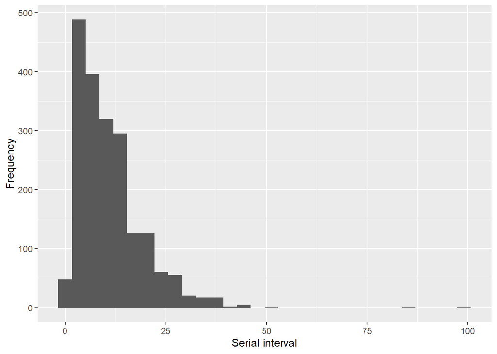

```r
tibble(si = si) %>%
  ggplot(aes(si)) +
  geom_histogram() +
  labs(
    x = "Serial interval",
    y = "Frequency"
  )
```

The `get_pairwise()` will interpret the class of the column being used for comparison, and will adjust its method of comparing the values accordingly. For numbers and dates (like the **si** example above), the function will subtract the values. When applied to columns that are characters or categorical, `get_pairwise()` will paste values together. Because the function also allows for arbitrary processing (see “f” argument), these discrete combinations can be easily tabulated and analyzed.

```r
head(get_pairwise(epic, "gender"), n = 10)
```

```
##  [1] "f -> m" NA       "m -> m" NA       "m -> f" "f -> f" NA       "f -> m"
##  [9] NA       "m -> f"
```

```r
get_pairwise(epic, "gender", f = table)
```

```
##            values.to
## values.from   f   m
##           f 464 516
##           m 510 468
```

```r
fisher.test(get_pairwise(epic, "gender", f = table))
```

```
##
##  Fisher's Exact Test for Count Data
##
## data:  get_pairwise(epic, "gender", f = table)
## p-value = 0.03758
## alternative hypothesis: true odds ratio is not equal to 1
## 95 percent confidence interval:
##  0.6882761 0.9892811
## sample estimates:
## odds ratio
##  0.8252575
```

Here, we see a significant association between transmission links and gender.

### Identifying clusters

The `get_clusters()` function can be used for to identify connected components in an `epicontacts` object. First, we use it to retrieve a `data.frame` containing the cluster information:

```r
clust <- get_clusters(epic, output = "data.frame")
table(clust$cluster_size)
```

```
##
##    1    2    3    4    5    6    7    8    9   10   11   12   13   14
## 1536 1680 1182  784  545  342  308  208  171  100   99   24   26   42
```

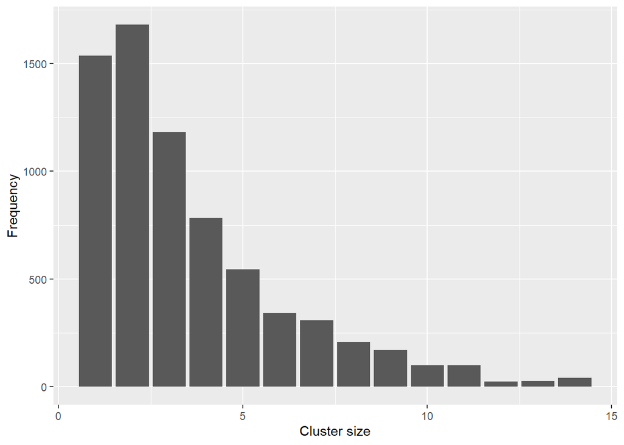

```r
ggplot(clust, aes(cluster_size)) +
  geom_bar() +
  labs(
    x = "Cluster size",
    y = "Frequency"
  )
```

Let us look at the largest clusters. For this, we add cluster information to the `epicontacts` object and then subset it to keep only the largest clusters:

```r
epic <- get_clusters(epic)
max_size <- max(epic$linelist$cluster_size)
plot(subset(epic, cs = max_size))
```

[interactive chart not shown]

### Calculating degrees

The degree of a node corresponds to its number of edges or connections to other nodes. `get_degree()` provides an easy method for calculating this value for `epicontacts` networks. A high degree in this context indicates an individual who was in contact with many others. The `type` argument indicates that we want to count both the in-degree and out-degree, the `only_linelist` argument indicates that we only want to calculate the degree for cases in the linelist.

```r
deg_both <- get_degree(epic, type = "both", only_linelist = TRUE)
```

Which individuals have the ten most contacts?

```r
head(sort(deg_both, decreasing = TRUE), 10)
```

```
## 916d0a 858426 6833d7 f093ea 11f8ea 3a4372 38fc71 c8c4d5 a127a7 02d8fd
##      7      6      6      6      5      5      5      5      5      5
```

What is the mean number of contacts?

```r
mean(deg_both)
```

```
## [1] 1.078473
```

## 38.6 Resources

The [epicontacts page](https://www.repidemicsconsortium.org/epicontacts/index.html) provides an overview of the package functions and includes some more in-depth vignettes.

The [github page](http://github.com/reconhub/epicontacts) can be used to raise issues and request features.

# 39 Phylogenetic trees

Placeholder

## 39.1 Overview

## 39.2 Preparation

### Load packages

### Import data

### Clean and inspect

## 39.3 Simple tree visualization

### Different tree layouts

### Simple tree plus sample data

## 39.4 Tree manipulation

### Zoom in

### Collapsing branches

### Subsetting a tree

### Rotating nodes in a tree

### Example subtree with sample data annotation

## More complex trees: adding heatmaps of sample data

## 39.5 Resources

# 40 Interactive plots

Placeholder

## 40.1 Preparation

### Load packages

### Start with a `ggplot()`

### Import data

## 40.2 Plot with `ggplotly()`

## 40.3 Modifications

### File size

### Buttons

## 40.4 Heat tiles

## 40.5 Resources

# 41 Reports with R Markdown

Placeholder

## 41.1 Preparation

## 41.2 Getting started

### Install rmarkdown R package

### Starting a new Rmd file

### Important to know

## 41.3 R Markdown components

### YAML metadata

### Text

#### New lines

#### Case

#### Color

#### Titles and headings

#### Bullets and numbering

#### Comment out text

### Code chunks

#### In-text R code

### Images

### Tables

### Tabbed sections

## 41.4 File structure

### Self-contained Rmd

#### Source other files

### Runfile

### Folder strucutre

## 41.5 Producing the document

### Option 1: “Knit” button

### Option 2: `render()` command

### Options 3: **reportfactory** package

## 41.6 Parameterised reports

### Setting parameters

#### Option 1: Set parameters within YAML

#### Option 2: Set parameters within `render()`

#### Option 3: Set parameters using a Graphical User Interface

### Parameterized example

### Parameterisation without `params`

## 41.7 Looping reports

## 41.8 Templates

### Word documents

### Powerpoint documents

### Integrating templates into the YAML

### Formatting HTML files

## 41.9 Dynamic content

### Tables

### HTML widgets

## 41.10 Resources

# 42 Organizing routine reports

Placeholder

## 42.1 Preparation

### Load packages

## 42.2 New factory

## 42.3 Create a report

## 42.4 Compile

### Compile by name

### Compile by number

### Compile all

### Compile from sub-folder

### Parameterization

### Using a “run-file”

## 42.5 Outputs

## 42.6 Miscellaneous

### Knit

### Scripts

### Extras

## 42.7 Resources

# 43 Dashboards with R Markdown

Placeholder

## 43.1 Preparation

### Load packages

### Import data

## 43.2 Create new R Markdown

## 43.3 The script

### YAML

### Code chunks

### Narrative text

### Headings

## 43.4 Section attributes

## 43.5 Layout

### Pages

### Orientation

### Tabs

## 43.6 Adding content

### Text

### Tables

### Plots

### Interactive plots

### HTML widgets

## 43.7 Code organization

## 43.8 Shiny

### Settings

### Worked example

### Other examples

## 43.9 Sharing

## 43.10 Resources

# 44 Dashboards with Shiny

Placeholder

## 44.1 Preparation

### Load packages

### Import data

## 44.2 The structure of a shiny app

### Basic file structures

### The server and the ui

### Before you start to build an app

## 44.3 Building a UI

## 44.4 Loading data into our app

## 44.5 Developing an app server

## 44.6 Adding more functionality

### Adding static text

### Adding a link

### Adding a download button

### Adding a facility selector

### Adding another tab with a table

## 44.7 Sharing shiny apps

## 44.8 Further reading

## 44.9 Recommended extension packages

## 44.10 Recommended resources

# 45 Writing functions

Placeholder

## 45.1 Preparation

### Load packages

### Import data

## 45.2 Functions

## 45.3 Why would you use a function?

## 45.4 How does R build functions?

## 45.5 Basic syntax and structure

## 45.6 Examples

### Return proportion tables for several columns

## 45.7 Using **purrr**: writing functions that can be iteratively applied

### Modify class of multiple columns in a dataset

### Iteratively produce graphs for different levels of a variable

### Iteratively produce tables for different levels of a variable

## 45.8 Tips and best Practices for well functioning functions

### Naming and syntax

### Column names and tidy evaluation

### Testing and Error handling

## 45.9 Resources

# 46 Directory interactions

Placeholder

## 46.1 Preparation

### **fs** package

### Print directory as a dendrogram tree

## 46.2 List files in a directory

## 46.3 File information

## 46.4 Check if exists

### R objects

### Directories

### Files

## 46.5 Create

### Directories

### Files

### Create if does not exists

## 46.6 Delete

### R objects

### Directories

### Files

## 46.7 Running other files

### `source()`

### `render()`

### Run files in a directory

### Import files in a directory

## 46.8 **base** R

## 46.9 Resources

# 47 Version control and collaboration with Git and Github

Placeholder

## 47.1 What is Git?

## 47.2 Why use the combo Git and Github?

### This sounds complicated, I am not a programmer

## 47.3 Setup

### Install Git

### Install an interface (optional but recommended)

### Github account

## 47.4 Vocabulary, concepts and basic functions

### Repository

### Commits

### Branches

### Local and remote repositories

## 47.5 Get started: create a new repository

### Start-up files

### Create a new repository in Github

### Clone from a Github repository

#### In Rstudio

#### In Github Desktop

### New Github repo from existing R project

### What does it look like now?

#### In RStudio

#### In Github Desktop

## 47.6 Git + Github workflow

### Process overview

## 47.7 Create a new branch

### In Rstudio Git pane

### In Github Desktop

### In console

## 47.8 Commit changes

### In Rstudio

### In Github Desktop

### In console

### Amend a previous commit

## 47.9 Pull and push changes up to Github

#### In Rstudio

#### In Github Desktop

#### Console

### I want to pull but I have local work

## 47.10 Merge branch into Main

### Locally in Github Desktop

### In console

### In Github: submitting pull requests

### Resolving conflicts

### Delete your branch

#### 47.10.0.1 Github + Rstudio

#### 47.10.0.2 In Github Desktop

### Forking

## 47.11 What we learned

## 47.12 Git commands

### Recommended learning

### Where to enter commands

### Sample commands

## 47.13 Resources

# 48 Common errors

Placeholder

## 48.1 Interpreting error messages

## 48.2 Common errors

### Typo errors

### Package errors

### Object errors

### Function syntax errors

### Logic errors

### Factor errors

### Plotting errors

### R Markdown errors

### Miscellaneous

## 48.3 Resources

# 49 Getting help

Placeholder

## 49.1 Github issues

## 49.2 Reproducible example

### The **reprex** package

### Minimal data

## 49.3 Posting to a forum

## 49.4 Resources

# 50 R on network drives

Placeholder

## 50.1 Overview

## 50.2 RStudio as administrator

## 50.3 Useful commands

## 50.4 Troubleshooting common errors

# 51 Data Table

Placeholder

## 51.1 Intro to data tables

## 51.2 Load packages and import data

### Load packages

### Import data

## 51.3 The i argument: selecting and filtering rows

### Using helper functions for filtering

## 51.4 The j argument: selecting and computing on columns

### Selecting columns

### Computing on columns

## 51.5 The by argument: computing by groups

## 51.6 Adding and updating to data tables

## 51.7 Resources